Datos 2019

# Organización y limpieza de los datos

Fuente: preciosclaros.gob.ar e INDEC  
Precios: Toallitas y tampones. Productos disponibles en la página al 05/03/2019

Contamos con 118.561 observaciones

- Variables del dataset

| names(datos) |
| --- |
| Categoria |
| Marca |
| Nombre |
| Presentacion |
| Comercio |
| Sucursal |
| Direccion |
| Localidad |
| Provincia |
| Precio.de.lista |

- Categorias

| Var1 | Freq |
| --- | --- |
| tampones | 26072 |
| toallitas | 92489 |

- Marcas

| Var1 | Freq |
| --- | --- |
| ALWAYS | 22128 |
| BONTÉ | 1932 |
| CALIPSO | 5492 |
| CAREFREE | 8 |
| CARREFOUR | 1978 |
| COOPERATIVA | 120 |
| COTIDIAN | 99 |
| DAYS | 50 |
| DÍA | 644 |
| DONCELLA | 903 |

[output cut: 20 more lines]

- Presentación

| Var1 | Freq |
| --- | --- |
| 1.0 un | 558 |
| 10.0 un | 8560 |
| 12.0 un | 241 |
| 14.0 un | 665 |
| 16.0 un | 38908 |
| 20.0 un | 8496 |
| 24.0 un | 1153 |
| 27.0 un | 1033 |
| 32.0 un | 2752 |
| 4.0 un | 80 |

[output cut: 6 more lines]

- Provincias

| Var1 | Freq |
| --- | --- |
| Buenos Aires | 38120 |
| CABA | 28288 |
| Catamarca | 594 |
| Chaco | 387 |
| Chubut | 2898 |
| Córdoba | 9428 |
| Corrientes | 845 |
| Entre Ríos | 2779 |
| Formosa | 329 |
| Jujuy | 2026 |

[output cut: 14 more lines]

*Precio de lista

```
   Min. 1st Qu.  Median    Mean 3rd Qu.    Max.
   3.49   57.29   77.99   85.45  108.89  312.00
```

Modifico la variable Presentacion, para quedarme con las unidades

| Var1 | Freq |
| --- | --- |
| 1 | 558 |
| 4 | 80 |
| 7 | 355 |
| 8 | 55417 |
| 10 | 8560 |
| 12 | 241 |
| 14 | 665 |
| 16 | 38908 |
| 20 | 8496 |
| 24 | 1153 |

[output cut: 6 more lines]

Hay casos que, de acuerdo a la descripción en Nombre, tienen mal la cantidad de unidades en Presentacion (y por ende en unidades), afectando el calculo de precios unitarios.

Utilizando expresiones regulares me quedo con los dígitos, sean uno o más, que están seguidos de “Un” o “un”.

| Var1 | Freq |
| --- | --- |
| 1 | 8 |
| 4 | 80 |
| 7 | 355 |
| 8 | 53827 |
| 10 | 8560 |
| 14 | 665 |
| 16 | 38082 |
| 20 | 8737 |
| 24 | 1153 |
| 30 | 443 |

[output cut: 4 more lines]

Corrijo las unidades, para que quede lo del regex en los casos en que no coincide.

| Var1 | Freq |
| --- | --- |
| 1 | 25 |
| 4 | 80 |
| 7 | 355 |
| 8 | 56027 |
| 10 | 8560 |
| 14 | 665 |
| 16 | 39756 |
| 20 | 8737 |
| 24 | 1153 |
| 30 | 443 |

[output cut: 3 more lines]

A partir de esta modifición baja la frecuencia de la presentación de 1 unidad, suben las de 8, 16 y 20 unidades, desaparecen las de 12, 27, 50 y 54 unidades, y aparece la de 30 unidades.

Calculo el Precio por unidad

```
   Min. 1st Qu.  Median    Mean 3rd Qu.    Max.
  0.220   5.280   7.000   6.989   8.440  35.750
```

Gráfico de boxplot de los precios unitarios por categoría

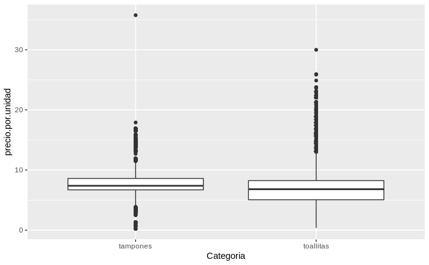

Cargo la estimación, por provincia, de personas que menstrúan. Esto sale de las proyecciones poblacionales del INDEC para 2019, teniendo en cuenta que la menarca se estima en los 13 años y la menopausia en 49 años. Estos datos se van a utilizar para ponderar el precio promedio de cada provincia a la hora de agregar en un indicador nacional.

Además, dada la cantidad de outliers vista en los gráficos de boxplot, a la hora de calcular los promedios de precios provinciales remuevo las colas, utilizando una media alfa podada:  
* alfa = 2.5%

# Resultados

## Total Nacional

### Toallitas

- Precio promedio por unidad

```
[1] "Toallitas: El precio promedio por unidad es de $ 6.73"
```

- Gasto por año por persona

Teniendo en cuenta:  
ciclos por año: 13  
productos utilizados por ciclo: 22

```
[1] "Toallitas: El gasto promedio por año por persona es de $ 1924.41"
```

### Tampones

- Precio promedio por unidad

```
[1] "Tampones: El precio promedio por unidad es de $ 7.47"
```

- Gasto por año por persona

Teniendo en cuenta:  
ciclos por año: 13  
productos utilizados por ciclo: 22

```
[1] "Tampones: El gasto promedio por año por persona es de $ 2136.84"
```

## Por provincia

### Toallitas

Gasto por año por persona, según provincia

| Provincia | gasto.por.anio |
| --- | --- |
| Buenos Aires | 1924.70 |
| CABA | 1973.06 |
| Catamarca | 1831.78 |
| Chaco | 1888.04 |
| Chubut | 2117.91 |
| Córdoba | 1881.50 |
| Corrientes | 1939.61 |
| Entre Ríos | 1952.01 |
| Formosa | 1875.26 |
| Jujuy | 1868.90 |

[output cut: 14 more lines]

### Tampones

Gasto por año por persona, según provincia

| Provincia | gasto.por.anio |
| --- | --- |
| Buenos Aires | 2101.23 |
| CABA | 2073.53 |
| Catamarca | 2278.06 |
| Chaco | 2120.93 |
| Chubut | 2146.67 |
| Córdoba | 2362.09 |
| Corrientes | 2108.37 |
| Entre Ríos | 1997.50 |
| Formosa | 1950.89 |
| Jujuy | 2232.51 |

[output cut: 14 more lines]